# Growth as a Data Person

I am at the primordial stage of my data science journey. This semester confirmed that data science is the path I want to explore further. As I wrote my Stats 518 project, “COVID-19 Mortality and Socioeconomic Trends in Michigan by County,” I gained a new appreciation for statistical computing, and I look forward to acquiring the knowledge to build complex models.

Before this class, I was comfortable analyzing, aggregating, and visualizing data at a base level. Up until this point, my experience wrangling data had an intense focus around consumer segmentation and behavior for the purpose of perpetuating consumerism. I heavily used point and click software that required a smidgen of SQL, like [Neustar Element One](https://www.home.neustar/resources/videos/elementone_demo). The software did all of the statistical heavy lifting.

While my project is not quite up to the bar I’ve set for myself, given that I was a true coding beginner with two statistics courses under my belt, I am proud of all that I’ve accomplished this semester. I had to prioritize functionality over form to meet the deadline (this hurts more than you may know), but I have confidence that with more time and skill I can create beautiful visualizations that will outshine my abilities in Tableau and MS Office suite.

### Here are a couple of examples of my growth:

Earlier this semester, I created tables and box plots comparing weight by gender with the ::starwars:: dataset. Compare this to where I am now, nearing the end of the semester, I connected to two separate open-source reports and plotted several dimensions in interactive scatte plots and tables. While there is beauty in the simplicity of the early visualizations, the coding skills needed to create the dynamic charts are more advanced.

#### **Mid-Semester Work**

[figure not shown]

The 17 Feminie Characters of Starwars.jpg

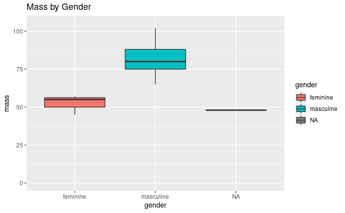

Box Plot by Weight

#### **End of Semester Work**

- [Dynamic Tables](https://073308-brooke.shinyapps.io/MIShiny/)
- [Dynamic Scatter Plot](https://rpubs.com/ekoorb03/plots_education)

###### —[Back to Table of Contents](https://github.com/BrookemWalters/BrookemWalters-Portfolio/blob/main/README.md)—